# Secondary Humanitarian Impacts of Ukraine Crisis

Last updated: 2022-04-19

## Data

### Current Crisis Severity

The [INFORM Severity Index](https://drmkc.jrc.ec.europa.eu/inform-index/INFORM-Severity/Methodology) defines severity as “a measure of the outcomes generated by the impact of a crisis, which can be exacerbated by the complexity of the operational environment”. It is designed to measure the severity of humanitarian crises globally against a common scale. It categorises all crises into five levels and tracks changes in crisis severity over time. It should not be used for decisions about the operational response to a specific crisis.

The plot below shows the current severity of crises with **more severe crises at the top** of the graph. It also shows the 3-month trend of the crisis where crisis that recently showed a **deterioration are listed in on the right-hand side** of the graph. Change in severity was computed by subtracting from the average of the last 3 months the average of the previous 3 months (months 4 - 6), per INFORM methodology.

[figure not shown]

### Trajectory of Food Security

| HRP | Country | Population | Current IPC3+ | Current IPC3+ (%) | Current IPC4 | Current IPC4 (%) | Current IPC5 | Current IPC5 (%) |
| --- | --- | --- | --- | --- | --- | --- | --- | --- |
| Yes | Afghanistan | 38,928,341 | 18,844,453 | 0.48 | 6,856,155 | 17.6 | 0 | 0.0 |
| Yes | Burkina Faso | 20,903,278 | 1,645,939 | 0.08 | 116,835 | 0.6 | 0 | 0.0 |
| Yes | Burundi | 11,890,781 | 1,057,992 | 0.09 | 0 | 0.0 | 0 | 0.0 |
| Yes | Cameroon | 26,545,864 | 2,430,111 | 0.09 | 157,238 | 0.6 | 0 | 0.0 |
| Yes | Central African Republic | 4,829,764 | 2,095,278 | 0.43 | 619,565 | 12.8 | 0 | 0.0 |
| Yes | Chad | 16,425,859 | 963,244 | 0.06 | 22,789 | 0.1 | 0 | 0.0 |
| Yes | Congo DRC | 89,561,404 | 27,020,164 | 0.30 | 6,104,757 | 6.8 | 0 | 0.0 |
| Yes | El Salvador | 6,486,201 | 841,190 | 0.13 | 60,879 | 0.9 | 0 | 0.0 |
| Yes | Ethiopia | 114,963,583 | 5,522,943 | 0.05 | 2,078,442 | 1.8 | 352,896 | 0.3 |
| Yes | Guatemala | 16,858,333 | 3,458,652 | 0.21 | 173,629 | 1.0 | 0 | 0.0 |
| Yes | Honduras | 9,904,608 | 2,227,597 | 0.22 | 240,652 | 2.4 | 0 | 0.0 |
| Yes | Libya | 6,825,442 | 0 | 0.00 | 0 | 0.0 | 0 | 0.0 |
| Yes | Mali | 27,691,019 | 1,161,527 | 0.04 | 47,160 | 0.2 | 0 | 0.0 |
| Yes | Mozambique | 31,255,435 | 1,857,640 | 0.06 | 39,208 | 0.1 | 0 | 0.0 |
| Yes | Niger | 24,206,636 | 2,578,385 | 0.11 | 148,583 | 0.6 | 0 | 0.0 |
| Yes | Nigeria | 206,139,587 | 12,936,583 | 0.06 | 228,708 | 0.1 | 0 | 0.0 |
| Yes | Somalia | 15,893,219 | 2,210,620 | 0.14 | 308,870 | 1.9 | 0 | 0.0 |
| Yes | South Sudan | 11,193,729 | 0 | 0.00 | 0 | 0.0 | 0 | 0.0 |
| Yes | Sudan | 43,849,269 | 7,298,273 | 0.17 | 1,841,160 | 4.2 | 0 | 0.0 |
| Yes | Syria | 17,500,657 | 0 | 0.00 | 0 | 0.0 | 0 | 0.0 |
| Yes | Yemen | 29,825,968 | 17,400,000 | 0.58 | 5,600,000 | 18.8 | 31,000 | 0.1 |
| No | Angola | 32,866,268 | 1,315,532 | 0.04 | 307,288 | 0.9 | 0 | 0.0 |
| No | Benin | 12,123,198 | 6,154 | 0.00 | 0 | 0.0 | 0 | 0.0 |
| No | Cote d’Ivoire | 26,378,275 | 944,561 | 0.04 | 0 | 0.0 | 0 | 0.0 |
| No | Eswatini | 1,160,164 | 261,839 | 0.23 | 21,615 | 1.9 | 0 | 0.0 |
| No | Gambia | 2,416,664 | 111,976 | 0.05 | 0 | 0.0 | 0 | 0.0 |
| No | Ghana | 31,072,945 | 563,800 | 0.02 | 85,569 | 0.3 | 0 | 0.0 |
| No | Guinea | 13,132,792 | 564,458 | 0.04 | 0 | 0.0 | 0 | 0.0 |
| No | GuineaBissau | 1,967,998 | 57,996 | 0.03 | 0 | 0.0 | 0 | 0.0 |
| No | Haiti (Grand Sud) | 11,402,533 | 979,897 | 0.09 | 319,988 | 2.8 | 0 | 0.0 |
| No | Haiti (Rural + Urban) | 11,402,533 | 4,333,426 | 0.38 | 1,337,763 | 11.7 | 0 | 0.0 |
| No | Kenya (LRA) | 9,904,608 | 2,147,839 | 0.22 | 354,633 | 3.6 | 0 | 0.0 |
| No | Kenya (SRA) | 9,904,608 | 1,425,209 | 0.14 | 238,555 | 2.4 | 0 | 0.0 |
| No | LAC Region (triNational) | 0 | 76,257 | 0.00 | 3,665 | 0.0 | 0 | 0.0 |
| No | Lebanon | 6,825,442 | 0 | 0.00 | 0 | 0.0 | 0 | 0.0 |
| No | Lesotho | 2,142,252 | 328,424 | 0.15 | 16,556 | 0.8 | 0 | 0.0 |
| No | Madagascar (Grand Sud/Est) | 2,142,252 | 1,642,643 | 0.77 | 404,775 | 18.9 | 0 | 0.0 |
| No | Malawi | 27,691,019 | 1,396,742 | 0.05 | 0 | 0.0 | 0 | 0.0 |
| No | Mauritania | 4,649,660 | 348,268 | 0.07 | 7,920 | 0.2 | 0 | 0.0 |
| No | Namibia | 2,540,916 | 658,588 | 0.26 | 101,630 | 4.0 | 0 | 0.0 |
| No | Pakistan | 220,892,331 | 4,658,928 | 0.02 | 1,091,368 | 0.5 | 0 | 0.0 |
| No | Senegal | 16,743,930 | 304,107 | 0.02 | 0 | 0.0 | 0 | 0.0 |
| No | Sierra Leone | 7,976,985 | 1,071,284 | 0.13 | 0 | 0.0 | 0 | 0.0 |
| No | Tanzania | 59,734,213 | 437,243 | 0.01 | 21,780 | 0.0 | 0 | 0.0 |
| No | Togo | 8,278,737 | 411,101 | 0.05 | 0 | 0.0 | 0 | 0.0 |
| No | Uganda | 45,741,000 | 360,910 | 0.01 | 75,140 | 0.2 | 0 | 0.0 |
| No | Zambia | 18,383,956 | 1,175,104 | 0.06 | 0 | 0.0 | 0 | 0.0 |

<sup>a</sup> Source: FewsNet, World Pop

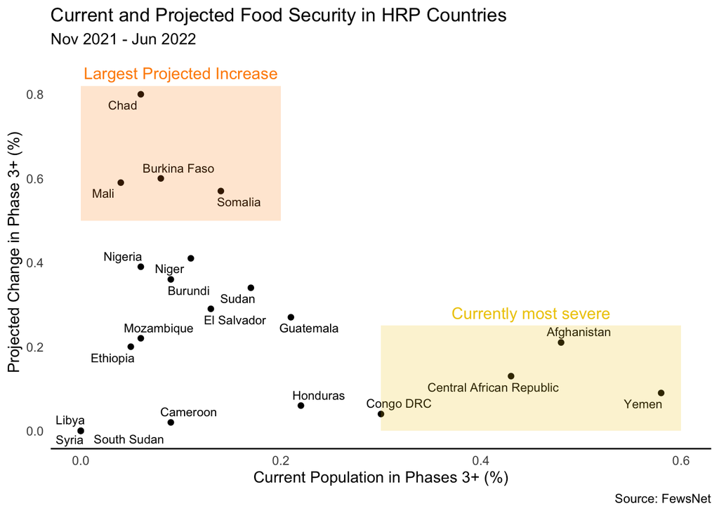

Countries projected to reach phase 5:

| HRP | country |
| --- | --- |
| Yes | Ethiopia |
| Yes | Nigeria |
| Yes | Yemen |

Countries projected to reach phase 4:

| HRP | country |
| --- | --- |
| Yes | Afghanistan |
| No | Angola |
| Yes | Burkina Faso |
| Yes | Cameroon |
| Yes | Central African Republic |
| Yes | Chad |
| Yes | Congo DRC |
| Yes | El Salvador |
| No | Eswatini |
| No | Gambia |

[output cut: 21 more lines]

Food security projections per phase in the table below.

| HRP | Country | Population | Projected Highest Projected Phase | Projected Change IPC3+ (%) | Projected Change IPC4 (%) | Projected Change IPC5 (%) |
| --- | --- | --- | --- | --- | --- | --- |
| Yes | Afghanistan | 38,928,341 | IPC 4 | 0.21 | 0.27 | 0.00 |
| Yes | Burkina Faso | 20,903,278 | IPC 4 | 0.60 | 2.74 | 0.00 |
| Yes | Burundi | 11,890,781 | IPC 3 | 0.36 | 0.00 | 0.00 |
| Yes | Cameroon | 26,545,864 | IPC 4 | 0.02 | 0.13 | 0.00 |
| Yes | Central African Republic | 4,829,764 | IPC 4 | 0.13 | 0.11 | 0.00 |
| Yes | Chad | 16,425,859 | IPC 4 | 0.80 | 5.29 | 0.00 |
| Yes | Congo DRC | 89,561,404 | IPC 4 | 0.04 | 0.11 | 0.00 |
| Yes | El Salvador | 6,486,201 | IPC 4 | 0.29 | 0.23 | 0.00 |
| Yes | Ethiopia | 114,963,583 | IPC5 | 0.20 | 0.13 | 0.14 |
| Yes | Guatemala | 16,858,333 | IPC 4 | 0.27 | 0.67 | 0.00 |
| Yes | Honduras | 9,904,608 | IPC 4 | 0.06 | 0.17 | 0.00 |
| Yes | Libya | 6,825,442 |  | 0.00 | 0.00 | 0.00 |
| Yes | Mali | 27,691,019 | IPC 4 | 0.59 | 2.32 | 0.00 |
| Yes | Mozambique | 31,255,435 | IPC 4 | 0.22 | 0.40 | 0.00 |
| Yes | Niger | 24,206,636 | IPC 4 | 0.41 | 1.02 | 0.00 |
| Yes | Nigeria | 206,139,587 | IPC 5 | 0.39 | 1.71 | 0.00 |
| Yes | Somalia | 15,893,219 | IPC 4 | 0.57 | 1.07 | 0.00 |
| Yes | South Sudan | 11,193,729 |  | 0.00 | 0.00 | 0.00 |
| Yes | Sudan | 43,849,269 | IPC 4 | 0.34 | 0.46 | 0.00 |
| Yes | Syria | 17,500,657 |  | 0.00 | 0.00 | 0.00 |
| Yes | Yemen | 29,825,968 | IPC 5 | 0.09 | 0.27 | 4.19 |
| No | Angola | 32,866,268 | IPC 4 | 0.20 | 0.36 | 0.00 |
| No | Benin | 12,123,198 | IPC 3 | 1.84 | 0.00 | 0.00 |
| No | Cote d’Ivoire | 26,378,275 | IPC 3 | 0.08 | 0.00 | 0.00 |
| No | Eswatini | 1,160,164 | IPC 4 | 0.21 | 1.29 | 0.00 |
| No | Gambia | 2,416,664 | IPC 4 | 0.85 | 0.00 | 0.00 |
| No | Ghana | 31,072,945 | IPC 4 | 0.51 | 0.88 | 0.00 |
| No | Guinea | 13,132,792 | IPC 3 | 0.31 | 0.00 | 0.00 |
| No | GuineaBissau | 1,967,998 | IPC 3 | 0.30 | 0.00 | 0.00 |
| No | Haiti (Grand Sud) | 11,402,533 | IPC 4 | 0.01 | 0.10 | 0.00 |
| No | Haiti (Rural + Urban) | 11,402,533 | IPC 4 | 0.05 | 0.00 | 0.00 |
| No | Kenya (LRA) | 9,904,608 | IPC 4 | 0.10 | 0.04 | 0.00 |
| No | Kenya (SRA) | 9,904,608 | IPC 4 | 0.41 | 0.00 | 0.00 |
| No | LAC Region (triNational) | 0 | IPC 4 | 0.37 | 1.03 | 0.00 |
| No | Lebanon | 6,825,442 |  | 0.00 | 0.00 | 0.00 |
| No | Lesotho | 2,142,252 | IPC 4 | 0.03 | 0.55 | 0.00 |
| No | Madagascar (Grand Sud/Est) | 2,142,252 | IPC 4 | 0.00 | 0.18 | 0.00 |
| No | Malawi | 27,691,019 | IPC 3 | 0.18 | 0.00 | 0.00 |
| No | Mauritania | 4,649,660 | IPC 4 | 0.90 | 3.26 | 0.00 |
| No | Namibia | 2,540,916 | IPC 4 | 0.14 | 0.17 | 0.00 |
| No | Pakistan | 220,892,331 | IPC 4 | 0.01 | 0.06 | 0.00 |
| No | Senegal | 16,743,930 | IPC 4 | 1.53 | 0.00 | 0.00 |
| No | Sierra Leone | 7,976,985 | IPC 3 | 0.36 | 0.00 | 0.00 |
| No | Tanzania | 59,734,213 | IPC 4 | 0.35 | 3.36 | 0.00 |
| No | Togo | 8,278,737 | IPC 3 | 0.17 | 0.00 | 0.00 |
| No | Uganda | 45,741,000 | IPC 4 | 0.48 | 0.63 | 0.00 |
| No | Zambia | 18,383,956 | IPC 3 | 0.34 | 0.00 | 0.00 |

<sup>a</sup> Source: FewsNet, World Pop

### Risk Exposure

The [INFORM Risk Score](https://drmkc.jrc.ec.europa.eu/inform-index/INFORM-Risk/Methodology) envisages three dimensions of risk, treated equally: hazards & exposure, vulnerability and lack of coping capacity. The **hazard & exposure** dimension reflects the probability of physical exposure associated with specific hazards. Physical vulnerability, which is a hazard-dependent characteristic, is included in the hazard & exposure dimension. **Vulnerability** addresses the intrinsic predispositions of an exposed population to be affected or to be susceptible to the damaging effects of a hazard as captured with hazard-independent indicators. It represents economic, political and social characteristics of the community that can be destabilized in case of a hazard event. The **coping capacity** dimension measures the ability of a country to cope with disasters in terms of formal, organized activities and the effort of the country’s government as well as the existing infrastructure which contribute to the reduction of disaster risk. The Risk Score can support decisions about prevention, preparedness and response.

| HRP | Country | Population | INFORM Score Risk Score | INFORM Score Risk Class | INFORM Dimensions Hazard & Exposure | INFORM Dimensions Vulnera- bility | INFORM Dimensions Coping Capacity |
| --- | --- | --- | --- | --- | --- | --- | --- |
| Yes | Afghanistan | 38,928,341 | 8.2 | Very High | 8.9 | 8.4 | 7.3 |
| Yes | Burkina Faso | 20,903,278 | 6.4 | High | 5.5 | 7.3 | 6.4 |
| Yes | Burundi | 11,890,781 | 5.9 | High | 4.7 | 6.3 | 6.8 |
| Yes | Cameroon | 26,545,864 | 6.1 | High | 5.6 | 6.6 | 6.1 |
| Yes | Central African Republic | 4,829,764 | 7.7 | Very High | 6.2 | 8.6 | 8.7 |
| Yes | Chad | 16,425,859 | 7.8 | Very High | 7.3 | 7.5 | 8.8 |
| Yes | Colombia | NA | 5.4 | High | 6.9 | 6.2 | 3.7 |
| Yes | El Salvador | 6,486,201 | 4.6 | Medium | 4.9 | 4.4 | 4.6 |
| Yes | Ethiopia | 114,963,583 | 6.9 | Very High | 7.3 | 6.5 | 6.8 |
| Yes | Guatemala | 16,858,333 | 5.4 | High | 5.2 | 5.7 | 5.4 |
| Yes | Haiti | NA | 6.3 | High | 5.8 | 5.9 | 7.3 |
| Yes | Honduras | 9,904,608 | 5.5 | High | 4.9 | 6.3 | 5.3 |
| Yes | Iraq | NA | 6.9 | Very High | 7.8 | 6.5 | 6.5 |
| Yes | Libya | 6,825,442 | 6.2 | High | 8.2 | 4.2 | 7.0 |
| Yes | Mali | 27,691,019 | 7.0 | Very High | 7.3 | 7.0 | 6.7 |
| Yes | Mozambique | 31,255,435 | 7.2 | Very High | 7.8 | 7.6 | 6.3 |
| Yes | Myanmar | NA | 6.2 | High | 7.4 | 5.1 | 6.3 |
| Yes | Niger | 24,206,636 | 7.4 | Very High | 7.3 | 7.2 | 7.6 |
| Yes | Nigeria | 206,139,587 | 6.5 | Very High | 7.3 | 5.7 | 6.5 |
| Yes | Somalia | 15,893,219 | 8.8 | Very High | 8.9 | 8.7 | 8.7 |
| Yes | South Sudan | 11,193,729 | 8.5 | Very High | 7.2 | 9.0 | 9.4 |
| Yes | Sudan | 43,849,269 | 6.4 | High | 5.7 | 6.8 | 6.7 |
| Yes | Syria | 17,500,657 | 7.2 | Very High | 8.7 | 8.0 | 5.4 |
| Yes | Ukraine | NA | 5.1 | High | 5.4 | 5.5 | 4.5 |
| Yes | Venezuela | NA | 4.8 | Medium | 5.5 | 4.2 | 4.9 |
| Yes | Yemen | 29,825,968 | 8.1 | Very High | 8.4 | 8.1 | 7.9 |
| No | Albania | NA | 2.8 | Low | 3.9 | 1.3 | 4.5 |
| No | Algeria | NA | 4.0 | Medium | 5.1 | 2.9 | 4.4 |
| No | Angola | 32,866,268 | 4.9 | Medium | 3.4 | 5.0 | 6.9 |
| No | Antigua and Barbuda | NA | 2.3 | Low | 2.2 | 1.5 | 3.6 |

[output cut: 161 more lines]

<sup>a</sup> Source: INFORM Risk, World Pop